# CSCN8010 Lab 10

# Notebook Title: Dogs vs Cats Classification with Vanilla CNN and Fine-Tuned VGG16

## 1. Introduction

This notebook explores the Dogs vs Cats dataset and compares the performance of two convolutional neural network (CNN) models: a Vanilla CNN and a Fine-Tuned VGG16 model. The goal is to classify images as either dogs or cats.

## 2. Importing Libraries

Import necessary libraries for data manipulation, visualization, and modeling:

- TensorFlow/Keras for deep learning
- Matplotlib and Seaborn for visualization
- Scikit-learn for metrics calculation

## 3. Data Preparation

### 3.1 Data Loading

Load the Dogs vs Cats dataset using TensorFlow Dataset API.

### 3.2 Data Exploration

Explore the dataset to understand its structure, size, and characteristics:

- Number of samples
- Distribution of classes (dogs vs cats)
- Sample images visualization

### 3.3 Data Preprocessing

Preprocess the images for modeling:

- Resize images to a consistent size
- Normalize pixel values

Split the dataset into training, validation, and test sets.

### 4.1 Model Architecture

Define the architecture of the Vanilla CNN model using TensorFlow/Keras:

### 4.2 Model Training

Train the Vanilla CNN model on the Dogs vs Cats dataset:

- Compile the model with appropriate loss function and optimizer
- Train the model using training data
- Monitor training metrics such as loss and accuracy

### 4.3 Model Evaluation

Evaluate the performance of the Vanilla CNN model on the test set:

- Calculate accuracy, precision, recall, and F1-score
- Visualize confusion matrix

## 5. Fine-Tuning VGG16 Model

### 5.1 Model Architecture

Load pre-trained VGG16 model with weights from ImageNet. Fine-tune the VGG16 model for Dogs vs Cats classification:

- Freeze initial layers and train only the top layers
- Modify the output layer for binary classification

### 5.2 Model Training

Train the Fine-Tuned VGG16 model on the Dogs vs Cats dataset:

- Compile the model with appropriate loss function and optimizer
- Train the model using training data
- Monitor training metrics such as loss and accuracy

### 5.3 Model Evaluation

Evaluate the performance of the Fine-Tuned VGG16 model on the test set:

## 6. Results and Analysis

Compare the performance of the Vanilla CNN and Fine-Tuned VGG16 models:

## 7. Conclusion

Summarize the findings from the experiments:

- Effectiveness of the models
- Challenges encountered
- Future directions for improving model performance or exploring related tasks

### **Import Libraries**

```python
import os
import numpy as np
import matplotlib.pyplot as plt
import seaborn as sns
from tensorflow.keras.preprocessing.image import ImageDataGenerator
from tensorflow.keras.models import Sequential
from tensorflow.keras.layers import Conv2D, MaxPooling2D, Flatten, Dense, Dropout
from tensorflow.keras.optimizers import Adam
from tensorflow.keras.callbacks import ModelCheckpoint
import tensorflow as tf
from tensorflow.keras.applications import VGG16
from tensorflow.keras.layers import Dense, Flatten
from tensorflow.keras.models import Model
from sklearn.metrics import confusion_matrix
from sklearn.metrics import precision_recall_curve
```

[figure not shown]

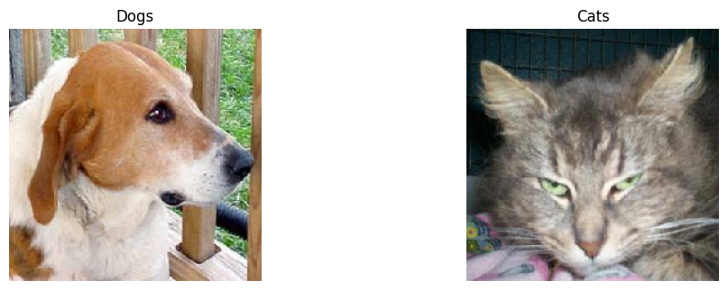

```python
## 3. Data Preparation

### 3.1 Data Loading
data_dir = ('./data/kaggle_dogs_vs_cats_small')
train_dir = os.path.join(data_dir, 'train')

# Count number of images in each class
num_dogs = len(os.listdir(os.path.join(train_dir, 'dogs')))
num_cats = len(os.listdir(os.path.join(train_dir, 'cats')))

### 3.2 Data Exploration

# Plot class distribution
plt.figure(figsize=(8, 6))
sns.countplot(x=['Dogs', 'Cats'], data={'Dogs': num_dogs, 'Cats': num_cats})
plt.title('Class Distribution')
plt.xlabel('Class')
plt.ylabel('Number of Images')
plt.show()

# Sample images visualization
plt.figure(figsize=(12, 8))
for i, (class_name, class_dir) in enumerate([('dogs', 'Dogs'), ('cats', 'Cats')]):
    img_name = np.random.choice(os.listdir(os.path.join(train_dir, class_dir)))
    img_path = os.path.join(train_dir, class_dir, img_name)
    img = load_img(img_path, target_size=(224, 224))  # Resize for visualization
    plt.subplot(2, 2, i+1)
    plt.imshow(img)
    plt.title(class_name.capitalize())
    plt.axis('off')
plt.show()
```

Simple neural network architecture for the Dogs vs Cats classification task and train two networks using callbacks to save the best model version.

```python
# Define data directory
data_dir = './data/kaggle_dogs_vs_cats_small'
train_dir = os.path.join(data_dir, 'train')
validation_dir = os.path.join(data_dir, 'validation')

# Define image dimensions
img_width, img_height = 150, 150

# Define batch size and epochs
batch_size = 32
epochs = 20

# Data preprocessing and augmentation
train_datagen = ImageDataGenerator(rescale=1.0/255,
                                   rotation_range=40,
                                   width_shift_range=0.2,
                                   height_shift_range=0.2,
                                   shear_range=0.2,
                                   zoom_range=0.2,
                                   horizontal_flip=True,
                                   fill_mode='nearest')

validation_datagen = ImageDataGenerator(rescale=1.0/255)

# Load datasets
train_dataset = train_datagen.flow_from_directory(train_dir,
                                                  target_size=(img_width, img_height),
                                                  batch_size=batch_size,
                                                  class_mode='binary')

validation_dataset = validation_datagen.flow_from_directory(validation_dir,
                                                            target_size=(img_width, img_height),
                                                            batch_size=batch_size,
                                                            class_mode='binary')

# Define the neural network architecture
def create_model(input_shape):
    model = Sequential([
        Conv2D(32, (3, 3), activation='relu', input_shape=input_shape),
        MaxPooling2D((2, 2)),
        Conv2D(64, (3, 3), activation='relu'),
        MaxPooling2D((2, 2)),
        Conv2D(128, (3, 3), activation='relu'),
        MaxPooling2D((2, 2)),
        Flatten(),
        Dense(128, activation='relu'),
        Dropout(0.5),
        Dense(1, activation='sigmoid')
    ])
    return model

# Define callbacks to save the best model version during training
checkpoint_path = "best_model.keras"  # Update filepath to end with .keras
checkpoint_callback = ModelCheckpoint(filepath=checkpoint_path,
                                      save_best_only=True,
                                      monitor='val_accuracy',
                                      mode='max',
                                      verbose=1)

# Create and compile the model
input_shape = (img_width, img_height, 3)
model = create_model(input_shape)
model.compile(optimizer='adam',
              loss='binary_crossentropy',
              metrics=['accuracy'])

# Train the model with callbacks
history = model.fit(train_dataset,
                    epochs=epochs,
                    batch_size=batch_size,
                    validation_data=validation_dataset,
                    callbacks=[checkpoint_callback])
```

```
Found 2000 images belonging to 2 classes.
Found 1000 images belonging to 2 classes.
```

```
63/63 ━━━━━━━━━━━━━━━━━━━━ 0s 909ms/step - accuracy: 0.5241 - loss: 0.7292
Epoch 1: val_accuracy improved from -inf to 0.50000, saving model to best_model.keras
63/63 ━━━━━━━━━━━━━━━━━━━━ 78s 1s/step - accuracy: 0.5240 - loss: 0.7288 - val_accuracy: 0.5000 - val_loss: 0.6912
63/63 ━━━━━━━━━━━━━━━━━━━━ 0s 558ms/step - accuracy: 0.5311 - loss: 0.6933
Epoch 2: val_accuracy improved from 0.50000 to 0.54400, saving model to best_model.keras
63/63 ━━━━━━━━━━━━━━━━━━━━ 41s 631ms/step - accuracy: 0.5312 - loss: 0.6933 - val_accuracy: 0.5440 - val_loss: 0.6782
63/63 ━━━━━━━━━━━━━━━━━━━━ 0s 567ms/step - accuracy: 0.5711 - loss: 0.6836
Epoch 3: val_accuracy improved from 0.54400 to 0.57400, saving model to best_model.keras
63/63 ━━━━━━━━━━━━━━━━━━━━ 42s 639ms/step - accuracy: 0.5710 - loss: 0.6836 - val_accuracy: 0.5740 - val_loss: 0.6587
63/63 ━━━━━━━━━━━━━━━━━━━━ 0s 571ms/step - accuracy: 0.5640 - loss: 0.6662
Epoch 4: val_accuracy improved from 0.57400 to 0.63100, saving model to best_model.keras
63/63 ━━━━━━━━━━━━━━━━━━━━ 42s 650ms/step - accuracy: 0.5640 - loss: 0.6662 - val_accuracy: 0.6310 - val_loss: 0.6613
63/63 ━━━━━━━━━━━━━━━━━━━━ 0s 581ms/step - accuracy: 0.5766 - loss: 0.6679
Epoch 5: val_accuracy improved from 0.63100 to 0.64200, saving model to best_model.keras
63/63 ━━━━━━━━━━━━━━━━━━━━ 43s 653ms/step - accuracy: 0.5768 - loss: 0.6678 - val_accuracy: 0.6420 - val_loss: 0.6427
63/63 ━━━━━━━━━━━━━━━━━━━━ 0s 560ms/step - accuracy: 0.6155 - loss: 0.6465
Epoch 6: val_accuracy did not improve from 0.64200
63/63 ━━━━━━━━━━━━━━━━━━━━ 41s 630ms/step - accuracy: 0.6155 - loss: 0.6465 - val_accuracy: 0.6410 - val_loss: 0.6321
63/63 ━━━━━━━━━━━━━━━━━━━━ 0s 586ms/step - accuracy: 0.6193 - loss: 0.6464
Epoch 7: val_accuracy improved from 0.64200 to 0.69700, saving model to best_model.keras
63/63 ━━━━━━━━━━━━━━━━━━━━ 43s 662ms/step - accuracy: 0.6194 - loss: 0.6463 - val_accuracy: 0.6970 - val_loss: 0.5980
63/63 ━━━━━━━━━━━━━━━━━━━━ 0s 551ms/step - accuracy: 0.6508 - loss: 0.6305
Epoch 8: val_accuracy did not improve from 0.69700
63/63 ━━━━━━━━━━━━━━━━━━━━ 41s 622ms/step - accuracy: 0.6509 - loss: 0.6303 - val_accuracy: 0.6590 - val_loss: 0.6281
63/63 ━━━━━━━━━━━━━━━━━━━━ 0s 545ms/step - accuracy: 0.6575 - loss: 0.6248
Epoch 9: val_accuracy improved from 0.69700 to 0.71100, saving model to best_model.keras
63/63 ━━━━━━━━━━━━━━━━━━━━ 40s 616ms/step - accuracy: 0.6575 - loss: 0.6247 - val_accuracy: 0.7110 - val_loss: 0.5698
63/63 ━━━━━━━━━━━━━━━━━━━━ 0s 556ms/step - accuracy: 0.6637 - loss: 0.6073
Epoch 10: val_accuracy did not improve from 0.71100
63/63 ━━━━━━━━━━━━━━━━━━━━ 42s 635ms/step - accuracy: 0.6636 - loss: 0.6074 - val_accuracy: 0.6530 - val_loss: 0.6383
63/63 ━━━━━━━━━━━━━━━━━━━━ 0s 563ms/step - accuracy: 0.6840 - loss: 0.6062
Epoch 11: val_accuracy did not improve from 0.71100
63/63 ━━━━━━━━━━━━━━━━━━━━ 41s 632ms/step - accuracy: 0.6840 - loss: 0.6061 - val_accuracy: 0.6410 - val_loss: 0.6028
63/63 ━━━━━━━━━━━━━━━━━━━━ 0s 546ms/step - accuracy: 0.6872 - loss: 0.5865
Epoch 12: val_accuracy improved from 0.71100 to 0.71700, saving model to best_model.keras
63/63 ━━━━━━━━━━━━━━━━━━━━ 41s 619ms/step - accuracy: 0.6871 - loss: 0.5866 - val_accuracy: 0.7170 - val_loss: 0.5484
63/63 ━━━━━━━━━━━━━━━━━━━━ 0s 549ms/step - accuracy: 0.6886 - loss: 0.5932
Epoch 13: val_accuracy did not improve from 0.71700
63/63 ━━━━━━━━━━━━━━━━━━━━ 40s 616ms/step - accuracy: 0.6885 - loss: 0.5932 - val_accuracy: 0.7100 - val_loss: 0.5567
63/63 ━━━━━━━━━━━━━━━━━━━━ 0s 547ms/step - accuracy: 0.6928 - loss: 0.6039
Epoch 14: val_accuracy did not improve from 0.71700
63/63 ━━━━━━━━━━━━━━━━━━━━ 40s 612ms/step - accuracy: 0.6930 - loss: 0.6035 - val_accuracy: 0.6350 - val_loss: 0.7570
63/63 ━━━━━━━━━━━━━━━━━━━━ 0s 602ms/step - accuracy: 0.6602 - loss: 0.6131
Epoch 15: val_accuracy did not improve from 0.71700
63/63 ━━━━━━━━━━━━━━━━━━━━ 44s 670ms/step - accuracy: 0.6604 - loss: 0.6129 - val_accuracy: 0.7050 - val_loss: 0.5444
63/63 ━━━━━━━━━━━━━━━━━━━━ 0s 559ms/step - accuracy: 0.6865 - loss: 0.5765
Epoch 16: val_accuracy improved from 0.71700 to 0.72300, saving model to best_model.keras
63/63 ━━━━━━━━━━━━━━━━━━━━ 42s 632ms/step - accuracy: 0.6866 - loss: 0.5765 - val_accuracy: 0.7230 - val_loss: 0.5425
63/63 ━━━━━━━━━━━━━━━━━━━━ 0s 562ms/step - accuracy: 0.7003 - loss: 0.5663
Epoch 17: val_accuracy improved from 0.72300 to 0.73300, saving model to best_model.keras
63/63 ━━━━━━━━━━━━━━━━━━━━ 42s 633ms/step - accuracy: 0.7002 - loss: 0.5665 - val_accuracy: 0.7330 - val_loss: 0.5358
63/63 ━━━━━━━━━━━━━━━━━━━━ 0s 542ms/step - accuracy: 0.6928 - loss: 0.5825
Epoch 18: val_accuracy improved from 0.73300 to 0.74300, saving model to best_model.keras
63/63 ━━━━━━━━━━━━━━━━━━━━ 41s 616ms/step - accuracy: 0.6929 - loss: 0.5825 - val_accuracy: 0.7430 - val_loss: 0.5158
63/63 ━━━━━━━━━━━━━━━━━━━━ 0s 549ms/step - accuracy: 0.7069 - loss: 0.5648
Epoch 19: val_accuracy did not improve from 0.74300
63/63 ━━━━━━━━━━━━━━━━━━━━ 41s 615ms/step - accuracy: 0.7069 - loss: 0.5647 - val_accuracy: 0.7120 - val_loss: 0.5400
63/63 ━━━━━━━━━━━━━━━━━━━━ 0s 550ms/step - accuracy: 0.7060 - loss: 0.5633
Epoch 20: val_accuracy did not improve from 0.74300
63/63 ━━━━━━━━━━━━━━━━━━━━ 41s 614ms/step - accuracy: 0.7061 - loss: 0.5633 - val_accuracy: 0.7400 - val_loss: 0.5263
```

Model training process has completed without any errors. The training process consists of 20 epochs, during which the model's performance on both the training and validation datasets has been monitored.

### Experiment with different architectures, such as adding more convolutional layers or increasing the number of neurons in the dense layers.

```python
# Define a deeper neural network architecture
def create_deeper_model(input_shape):
    model = Sequential([
        Conv2D(32, (3, 3), activation='relu', input_shape=input_shape),
        MaxPooling2D((2, 2)),
        Conv2D(64, (3, 3), activation='relu'),
        MaxPooling2D((2, 2)),
        Conv2D(128, (3, 3), activation='relu'),
        MaxPooling2D((2, 2)),
        Conv2D(256, (3, 3), activation='relu'),  # Additional convolutional layer
        MaxPooling2D((2, 2)),
        Flatten(),
        Dense(256, activation='relu'),  # Increase the number of neurons in dense layer
        Dropout(0.5),
        Dense(1, activation='sigmoid')
    ])
    return model

# Create and compile the deeper model
deeper_model = create_deeper_model(input_shape)
deeper_model.compile(optimizer='adam',
                     loss='binary_crossentropy',
                     metrics=['accuracy'])

# Train the deeper model
deeper_history = deeper_model.fit(train_dataset,
                                  epochs=epochs,
                                  batch_size=batch_size,
                                  validation_data=validation_dataset,
                                  callbacks=[checkpoint_callback])
```

```
63/63 ━━━━━━━━━━━━━━━━━━━━ 0s 640ms/step - accuracy: 0.5172 - loss: 0.7020
Epoch 1: val_accuracy did not improve from 0.74300
63/63 ━━━━━━━━━━━━━━━━━━━━ 51s 739ms/step - accuracy: 0.5171 - loss: 0.7019 - val_accuracy: 0.5000 - val_loss: 0.6927
63/63 ━━━━━━━━━━━━━━━━━━━━ 0s 663ms/step - accuracy: 0.5093 - loss: 0.6938
Epoch 2: val_accuracy did not improve from 0.74300
63/63 ━━━━━━━━━━━━━━━━━━━━ 49s 749ms/step - accuracy: 0.5093 - loss: 0.6938 - val_accuracy: 0.5000 - val_loss: 0.6917
63/63 ━━━━━━━━━━━━━━━━━━━━ 0s 675ms/step - accuracy: 0.4963 - loss: 0.6940
Epoch 3: val_accuracy did not improve from 0.74300
63/63 ━━━━━━━━━━━━━━━━━━━━ 49s 752ms/step - accuracy: 0.4965 - loss: 0.6940 - val_accuracy: 0.5110 - val_loss: 0.6889
63/63 ━━━━━━━━━━━━━━━━━━━━ 0s 649ms/step - accuracy: 0.5403 - loss: 0.6894
Epoch 4: val_accuracy did not improve from 0.74300
63/63 ━━━━━━━━━━━━━━━━━━━━ 48s 734ms/step - accuracy: 0.5402 - loss: 0.6894 - val_accuracy: 0.5510 - val_loss: 0.6847
63/63 ━━━━━━━━━━━━━━━━━━━━ 0s 646ms/step - accuracy: 0.5254 - loss: 0.6898
Epoch 5: val_accuracy did not improve from 0.74300
63/63 ━━━━━━━━━━━━━━━━━━━━ 47s 723ms/step - accuracy: 0.5255 - loss: 0.6898 - val_accuracy: 0.5220 - val_loss: 0.6882
63/63 ━━━━━━━━━━━━━━━━━━━━ 0s 623ms/step - accuracy: 0.5508 - loss: 0.6860
Epoch 6: val_accuracy did not improve from 0.74300
63/63 ━━━━━━━━━━━━━━━━━━━━ 47s 705ms/step - accuracy: 0.5509 - loss: 0.6860 - val_accuracy: 0.5870 - val_loss: 0.6660
63/63 ━━━━━━━━━━━━━━━━━━━━ 0s 839ms/step - accuracy: 0.5923 - loss: 0.6740
Epoch 7: val_accuracy did not improve from 0.74300
63/63 ━━━━━━━━━━━━━━━━━━━━ 60s 927ms/step - accuracy: 0.5921 - loss: 0.6740 - val_accuracy: 0.6090 - val_loss: 0.6383
63/63 ━━━━━━━━━━━━━━━━━━━━ 0s 688ms/step - accuracy: 0.5872 - loss: 0.6717
Epoch 8: val_accuracy did not improve from 0.74300
63/63 ━━━━━━━━━━━━━━━━━━━━ 51s 783ms/step - accuracy: 0.5869 - loss: 0.6718 - val_accuracy: 0.6440 - val_loss: 0.6577
63/63 ━━━━━━━━━━━━━━━━━━━━ 0s 717ms/step - accuracy: 0.5687 - loss: 0.6779
Epoch 9: val_accuracy did not improve from 0.74300
63/63 ━━━━━━━━━━━━━━━━━━━━ 53s 798ms/step - accuracy: 0.5689 - loss: 0.6778 - val_accuracy: 0.5770 - val_loss: 0.6592
63/63 ━━━━━━━━━━━━━━━━━━━━ 0s 658ms/step - accuracy: 0.5800 - loss: 0.6747
Epoch 10: val_accuracy did not improve from 0.74300
63/63 ━━━━━━━━━━━━━━━━━━━━ 48s 739ms/step - accuracy: 0.5802 - loss: 0.6745 - val_accuracy: 0.6430 - val_loss: 0.6434
63/63 ━━━━━━━━━━━━━━━━━━━━ 0s 632ms/step - accuracy: 0.6210 - loss: 0.6623
Epoch 11: val_accuracy did not improve from 0.74300
63/63 ━━━━━━━━━━━━━━━━━━━━ 46s 713ms/step - accuracy: 0.6211 - loss: 0.6623 - val_accuracy: 0.6480 - val_loss: 0.6316
63/63 ━━━━━━━━━━━━━━━━━━━━ 0s 594ms/step - accuracy: 0.6201 - loss: 0.6552
Epoch 12: val_accuracy did not improve from 0.74300
63/63 ━━━━━━━━━━━━━━━━━━━━ 44s 670ms/step - accuracy: 0.6202 - loss: 0.6550 - val_accuracy: 0.6050 - val_loss: 0.6520
63/63 ━━━━━━━━━━━━━━━━━━━━ 0s 592ms/step - accuracy: 0.6328 - loss: 0.6432
Epoch 13: val_accuracy did not improve from 0.74300
63/63 ━━━━━━━━━━━━━━━━━━━━ 44s 670ms/step - accuracy: 0.6331 - loss: 0.6431 - val_accuracy: 0.6480 - val_loss: 0.6271
63/63 ━━━━━━━━━━━━━━━━━━━━ 0s 608ms/step - accuracy: 0.6325 - loss: 0.6418
Epoch 14: val_accuracy did not improve from 0.74300
63/63 ━━━━━━━━━━━━━━━━━━━━ 45s 684ms/step - accuracy: 0.6327 - loss: 0.6417 - val_accuracy: 0.6800 - val_loss: 0.6035
63/63 ━━━━━━━━━━━━━━━━━━━━ 0s 599ms/step - accuracy: 0.6639 - loss: 0.6017
Epoch 15: val_accuracy did not improve from 0.74300
63/63 ━━━━━━━━━━━━━━━━━━━━ 44s 673ms/step - accuracy: 0.6639 - loss: 0.6018 - val_accuracy: 0.6910 - val_loss: 0.5959
63/63 ━━━━━━━━━━━━━━━━━━━━ 0s 605ms/step - accuracy: 0.6671 - loss: 0.6091
Epoch 16: val_accuracy did not improve from 0.74300
63/63 ━━━━━━━━━━━━━━━━━━━━ 45s 683ms/step - accuracy: 0.6673 - loss: 0.6091 - val_accuracy: 0.6890 - val_loss: 0.5851
63/63 ━━━━━━━━━━━━━━━━━━━━ 0s 605ms/step - accuracy: 0.7001 - loss: 0.5836
Epoch 17: val_accuracy did not improve from 0.74300
63/63 ━━━━━━━━━━━━━━━━━━━━ 45s 681ms/step - accuracy: 0.6999 - loss: 0.5837 - val_accuracy: 0.6910 - val_loss: 0.5633
63/63 ━━━━━━━━━━━━━━━━━━━━ 0s 595ms/step - accuracy: 0.7122 - loss: 0.5753
Epoch 18: val_accuracy did not improve from 0.74300
63/63 ━━━━━━━━━━━━━━━━━━━━ 44s 672ms/step - accuracy: 0.7119 - loss: 0.5756 - val_accuracy: 0.6900 - val_loss: 0.5544
63/63 ━━━━━━━━━━━━━━━━━━━━ 0s 601ms/step - accuracy: 0.7065 - loss: 0.5655
Epoch 19: val_accuracy did not improve from 0.74300
63/63 ━━━━━━━━━━━━━━━━━━━━ 44s 680ms/step - accuracy: 0.7064 - loss: 0.5656 - val_accuracy: 0.7280 - val_loss: 0.5562
63/63 ━━━━━━━━━━━━━━━━━━━━ 0s 605ms/step - accuracy: 0.7118 - loss: 0.5557
Epoch 20: val_accuracy did not improve from 0.74300
63/63 ━━━━━━━━━━━━━━━━━━━━ 45s 687ms/step - accuracy: 0.7116 - loss: 0.5560 - val_accuracy: 0.7200 - val_loss: 0.5515
```

```python
from tensorflow.keras.optimizers import SGD
# Define a new optimizer (e.g., SGD with a different learning rate)
sgd_optimizer = SGD(learning_rate=0.01)

# Compile the model with the new optimizer
model.compile(optimizer=sgd_optimizer,
              loss='binary_crossentropy',
              metrics=['accuracy'])
```

### Explore alternative loss functions suitable for binary classification tasks

```python
# Define a new loss function (e.g., hinge loss)
def hinge_loss(y_true, y_pred):
    return tf.losses.hinge(y_true, y_pred)

# Compile the model with the new loss function
model.compile(optimizer='adam',
              loss=hinge_loss,
              metrics=['accuracy'])
```

### Adjust the batch size, number of epochs, and data augmentation techniques.

```python
# Check data formatting
print("Train Dataset Size:", train_dataset.samples)
print("Validation Dataset Size:", validation_dataset.samples)

# Get a sample batch from the train_dataset
sample_batch = next(train_dataset)
images, labels = sample_batch

# Inspect the sample batch
print("Sample Batch Shape (Images):", images.shape)
print("Sample Batch Shape (Labels):", labels.shape)
```

```
Train Dataset Size: 2000
Validation Dataset Size: 1000
Sample Batch Shape (Images): (32, 150, 150, 3)
Sample Batch Shape (Labels): (32,)
```

```
Found 2000 images belonging to 2 classes.
Found 1000 images belonging to 2 classes.
100/100 - 241s - 2s/step - accuracy: 0.7355 - loss: 0.5150 - val_accuracy: 0.8650 - val_loss: 0.3130
100/100 - 0s - 2ms/step - accuracy: 0.0000e+00 - loss: 0.0000e+00 - val_accuracy: 0.0000e+00 - val_loss: 0.0000e+00
```

```
100/100 - 267s - 3s/step - accuracy: 0.8315 - loss: 0.3792 - val_accuracy: 0.8970 - val_loss: 0.2704
100/100 - 0s - 646us/step - accuracy: 0.0000e+00 - loss: 0.0000e+00 - val_accuracy: 0.0000e+00 - val_loss: 0.0000e+00
100/100 - 266s - 3s/step - accuracy: 0.8405 - loss: 0.3544 - val_accuracy: 0.8980 - val_loss: 0.2550
100/100 - 0s - 888us/step - accuracy: 0.0000e+00 - loss: 0.0000e+00 - val_accuracy: 0.0000e+00 - val_loss: 0.0000e+00
100/100 - 278s - 3s/step - accuracy: 0.8380 - loss: 0.3547 - val_accuracy: 0.9060 - val_loss: 0.2516
100/100 - 0s - 968us/step - accuracy: 0.0000e+00 - loss: 0.0000e+00 - val_accuracy: 0.0000e+00 - val_loss: 0.0000e+00
100/100 - 293s - 3s/step - accuracy: 0.8550 - loss: 0.3360 - val_accuracy: 0.8950 - val_loss: 0.2545
100/100 - 0s - 768us/step - accuracy: 0.0000e+00 - loss: 0.0000e+00 - val_accuracy: 0.0000e+00 - val_loss: 0.0000e+00
100/100 - 319s - 3s/step - accuracy: 0.8670 - loss: 0.3227 - val_accuracy: 0.9010 - val_loss: 0.2425
100/100 - 0s - 1ms/step - accuracy: 0.0000e+00 - loss: 0.0000e+00 - val_accuracy: 0.0000e+00 - val_loss: 0.0000e+00
100/100 - 305s - 3s/step - accuracy: 0.8720 - loss: 0.3020 - val_accuracy: 0.9090 - val_loss: 0.2369
100/100 - 0s - 625us/step - accuracy: 0.0000e+00 - loss: 0.0000e+00 - val_accuracy: 0.0000e+00 - val_loss: 0.0000e+00
100/100 - 268s - 3s/step - accuracy: 0.8560 - loss: 0.3160 - val_accuracy: 0.8760 - val_loss: 0.2800
100/100 - 0s - 968us/step - accuracy: 0.0000e+00 - loss: 0.0000e+00 - val_accuracy: 0.0000e+00 - val_loss: 0.0000e+00
100/100 - 345s - 3s/step - accuracy: 0.8705 - loss: 0.2987 - val_accuracy: 0.9050 - val_loss: 0.2367
100/100 - 0s - 1ms/step - accuracy: 0.0000e+00 - loss: 0.0000e+00 - val_accuracy: 0.0000e+00 - val_loss: 0.0000e+00
100/100 - 361s - 4s/step - accuracy: 0.8650 - loss: 0.3020 - val_accuracy: 0.9040 - val_loss: 0.2383
100/100 - 0s - 781us/step - accuracy: 0.0000e+00 - loss: 0.0000e+00 - val_accuracy: 0.0000e+00 - val_loss: 0.0000e+00
100/100 - 359s - 4s/step - accuracy: 0.8830 - loss: 0.2861 - val_accuracy: 0.9000 - val_loss: 0.2433
100/100 - 0s - 825us/step - accuracy: 0.0000e+00 - loss: 0.0000e+00 - val_accuracy: 0.0000e+00 - val_loss: 0.0000e+00
100/100 - 327s - 3s/step - accuracy: 0.8695 - loss: 0.2858 - val_accuracy: 0.9020 - val_loss: 0.2378
100/100 - 0s - 1ms/step - accuracy: 0.0000e+00 - loss: 0.0000e+00 - val_accuracy: 0.0000e+00 - val_loss: 0.0000e+00
100/100 - 328s - 3s/step - accuracy: 0.8700 - loss: 0.2960 - val_accuracy: 0.9050 - val_loss: 0.2380
100/100 - 0s - 1ms/step - accuracy: 0.0000e+00 - loss: 0.0000e+00 - val_accuracy: 0.0000e+00 - val_loss: 0.0000e+00
100/100 - 324s - 3s/step - accuracy: 0.8820 - loss: 0.2702 - val_accuracy: 0.9040 - val_loss: 0.2352
100/100 - 0s - 589us/step - accuracy: 0.0000e+00 - loss: 0.0000e+00 - val_accuracy: 0.0000e+00 - val_loss: 0.0000e+00
100/100 - 317s - 3s/step - accuracy: 0.8820 - loss: 0.2706 - val_accuracy: 0.9020 - val_loss: 0.2393
100/100 - 0s - 1ms/step - accuracy: 0.0000e+00 - loss: 0.0000e+00 - val_accuracy: 0.0000e+00 - val_loss: 0.0000e+00
```

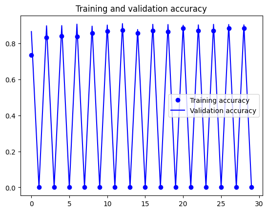

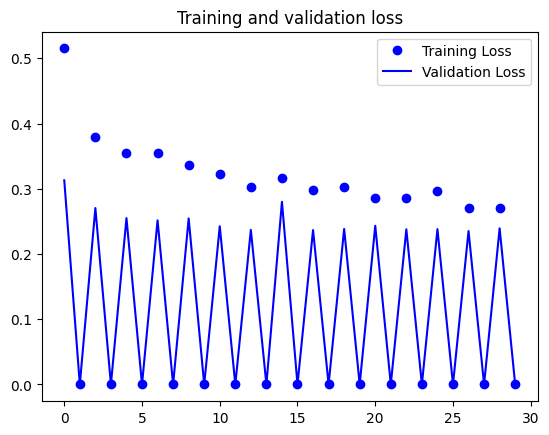

```python
# Load pre-trained VGG16 model
vgg_base = VGG16(weights='imagenet', include_top=False, input_shape=(150, 150, 3))

# Freeze convolutional layers
for layer in vgg_base.layers:
    layer.trainable = False

# Add custom classification layers
flatten_layer = Flatten()(vgg_base.output)
dense_layer = Dense(256, activation='relu')(flatten_layer)
output = Dense(1, activation='sigmoid')(dense_layer)

# Create the model
model = Model(inputs=vgg_base.input, outputs=output)

# Compile the model
model.compile(optimizer=Adam(learning_rate=1e-4), loss='binary_crossentropy', metrics=['accuracy'])

# Data Augmentation
train_datagen = ImageDataGenerator(rescale=1./255, rotation_range=40,
                                   width_shift_range=0.2, height_shift_range=0.2,
                                   shear_range=0.2, zoom_range=0.2, horizontal_flip=True)
validation_datagen = ImageDataGenerator(rescale=1./255)

# Flow training images in batches of 20 using train_datagen generator
train_generator = train_datagen.flow_from_directory(
        train_dir,  # This is the source directory for training images
        target_size=(150, 150),  # All images will be resized to 150x150
        batch_size=20,
        class_mode='binary')

# Flow validation images in batches of 20 using validation_datagen generator
validation_generator = validation_datagen.flow_from_directory(
        validation_dir,
        target_size=(150, 150),
        batch_size=20,
        class_mode='binary')

# Train the model
history = model.fit(
      train_generator,
      steps_per_epoch=100,  # 2000 images = batch_size * steps
      epochs=30,
      validation_data=validation_generator,
      validation_steps=50,  # 1000 images = batch_size * steps
      verbose=2)

# Plotting the training and validation accuracy
import matplotlib.pyplot as plt

acc = history.history['accuracy']
val_acc = history.history['val_accuracy']
loss = history.history['loss']
val_loss = history.history['val_loss']

epochs = range(len(acc))

plt.plot(epochs, acc, 'bo', label='Training accuracy')
plt.plot(epochs, val_acc, 'b', label='Validation accuracy')
plt.title('Training and validation accuracy')
plt.legend()

plt.figure()

plt.plot(epochs, loss, 'bo', label='Training Loss')
plt.plot(epochs, val_loss, 'b', label='Validation Loss')
plt.title('Training and validation loss')
plt.legend()

plt.show()
```

### Load the best versions of each model and evaluate their performance:

```python
import os
import tensorflow as tf
from tensorflow.keras.preprocessing.image import ImageDataGenerator
from tensorflow.keras.applications import VGG16, ResNet50
from tensorflow.keras.models import Sequential
from tensorflow.keras.layers import Dense, Flatten, Dropout
from sklearn.metrics import classification_report, confusion_matrix, precision_recall_curve
import numpy as np
from sklearn.metrics import classification_report
# Define data directories
data_dir = './data/kaggle_dogs_vs_cats_small'
train_dir = os.path.join(data_dir, 'train')
validation_dir = os.path.join(data_dir, 'validation')

# Define model architecture
base_model = VGG16(weights='imagenet', include_top=False, input_shape=(150, 150, 3))
model = Sequential([
    base_model,
    Flatten(),
    Dense(256, activation='relu'),
    Dropout(0.5),
    Dense(1, activation='sigmoid')
])

# Compile the model
model.compile(optimizer='adam', loss='binary_crossentropy', metrics=['accuracy'])

# Data augmentation
train_datagen = ImageDataGenerator(
    rescale=1./255,
    rotation_range=40,
    width_shift_range=0.2,
    height_shift_range=0.2,
    shear_range=0.2,
    zoom_range=0.2,
    horizontal_flip=True,
    fill_mode='nearest'
)

train_generator = train_datagen.flow_from_directory(
    train_dir,
    target_size=(150, 150),
    batch_size=20,
    class_mode='binary'
)

validation_datagen = ImageDataGenerator(rescale=1./255)

validation_generator = validation_datagen.flow_from_directory(
    validation_dir,
    target_size=(150, 150),
    batch_size=20,
    class_mode='binary'
)

# Train the model
history = model.fit(
    train_generator,
    steps_per_epoch=100,
    epochs=30,
    validation_data=validation_generator,
    validation_steps=50
)

# Evaluate the model
validation_loss, validation_accuracy = model.evaluate(validation_generator)
print(f'Validation Loss: {validation_loss:.2f}')
print(f'Validation Accuracy: {validation_accuracy:.2f}')

# Save the model
model.save('best_model_vgg16.h5')
```

```
Found 2000 images belonging to 2 classes.
Found 1000 images belonging to 2 classes.
```

```
100/100 ━━━━━━━━━━━━━━━━━━━━ 1038s 10s/step - accuracy: 0.5269 - loss: 1.8936 - val_accuracy: 0.5000 - val_loss: 0.7080
100/100 ━━━━━━━━━━━━━━━━━━━━ 0s 2ms/step - accuracy: 0.0000e+00 - loss: 0.0000e+00 - val_accuracy: 0.0000e+00 - val_loss: 0.0000e+00
```

```
100/100 ━━━━━━━━━━━━━━━━━━━━ 1057s 11s/step - accuracy: 0.4881 - loss: 0.6980 - val_accuracy: 0.5000 - val_loss: 0.6929
100/100 ━━━━━━━━━━━━━━━━━━━━ 0s 1ms/step - accuracy: 0.0000e+00 - loss: 0.0000e+00 - val_accuracy: 0.0000e+00 - val_loss: 0.0000e+00
100/100 ━━━━━━━━━━━━━━━━━━━━ 1571s 16s/step - accuracy: 0.5208 - loss: 0.6919 - val_accuracy: 0.5000 - val_loss: 0.6934
100/100 ━━━━━━━━━━━━━━━━━━━━ 0s 2ms/step - accuracy: 0.0000e+00 - loss: 0.0000e+00 - val_accuracy: 0.0000e+00 - val_loss: 0.0000e+00
100/100 ━━━━━━━━━━━━━━━━━━━━ 1086s 11s/step - accuracy: 0.5076 - loss: 0.6931 - val_accuracy: 0.5000 - val_loss: 0.6932
100/100 ━━━━━━━━━━━━━━━━━━━━ 0s 1ms/step - accuracy: 0.0000e+00 - loss: 0.0000e+00 - val_accuracy: 0.0000e+00 - val_loss: 0.0000e+00
100/100 ━━━━━━━━━━━━━━━━━━━━ 1235s 12s/step - accuracy: 0.5164 - loss: 0.6930 - val_accuracy: 0.5000 - val_loss: 0.6932
100/100 ━━━━━━━━━━━━━━━━━━━━ 0s 1ms/step - accuracy: 0.0000e+00 - loss: 0.0000e+00 - val_accuracy: 0.0000e+00 - val_loss: 0.0000e+00
100/100 ━━━━━━━━━━━━━━━━━━━━ 1174s 12s/step - accuracy: 0.5179 - loss: 0.6928 - val_accuracy: 0.5000 - val_loss: 0.6932
100/100 ━━━━━━━━━━━━━━━━━━━━ 0s 2ms/step - accuracy: 0.0000e+00 - loss: 0.0000e+00 - val_accuracy: 0.0000e+00 - val_loss: 0.0000e+00
100/100 ━━━━━━━━━━━━━━━━━━━━ 1040s 10s/step - accuracy: 0.4884 - loss: 0.6932 - val_accuracy: 0.5000 - val_loss: 0.6932
100/100 ━━━━━━━━━━━━━━━━━━━━ 0s 1ms/step - accuracy: 0.0000e+00 - loss: 0.0000e+00 - val_accuracy: 0.0000e+00 - val_loss: 0.0000e+00
100/100 ━━━━━━━━━━━━━━━━━━━━ 1189s 12s/step - accuracy: 0.4819 - loss: 0.6933 - val_accuracy: 0.5000 - val_loss: 0.6932
100/100 ━━━━━━━━━━━━━━━━━━━━ 0s 2ms/step - accuracy: 0.0000e+00 - loss: 0.0000e+00 - val_accuracy: 0.0000e+00 - val_loss: 0.0000e+00
100/100 ━━━━━━━━━━━━━━━━━━━━ 1233s 12s/step - accuracy: 0.4893 - loss: 0.6932 - val_accuracy: 0.5000 - val_loss: 0.6931
100/100 ━━━━━━━━━━━━━━━━━━━━ 0s 1ms/step - accuracy: 0.0000e+00 - loss: 0.0000e+00 - val_accuracy: 0.0000e+00 - val_loss: 0.0000e+00
100/100 ━━━━━━━━━━━━━━━━━━━━ 1907s 19s/step - accuracy: 0.5265 - loss: 0.6931 - val_accuracy: 0.5000 - val_loss: 0.6931
100/100 ━━━━━━━━━━━━━━━━━━━━ 0s 1ms/step - accuracy: 0.0000e+00 - loss: 0.0000e+00 - val_accuracy: 0.0000e+00 - val_loss: 0.0000e+00
100/100 ━━━━━━━━━━━━━━━━━━━━ 1347s 13s/step - accuracy: 0.5021 - loss: 0.6932 - val_accuracy: 0.5000 - val_loss: 0.6931
100/100 ━━━━━━━━━━━━━━━━━━━━ 0s 660us/step - accuracy: 0.0000e+00 - loss: 0.0000e+00 - val_accuracy: 0.0000e+00 - val_loss: 0.0000e+00
100/100 ━━━━━━━━━━━━━━━━━━━━ 1555s 16s/step - accuracy: 0.4922 - loss: 0.6931 - val_accuracy: 0.5000 - val_loss: 0.6931
100/100 ━━━━━━━━━━━━━━━━━━━━ 0s 838us/step - accuracy: 0.0000e+00 - loss: 0.0000e+00 - val_accuracy: 0.0000e+00 - val_loss: 0.0000e+00
100/100 ━━━━━━━━━━━━━━━━━━━━ 21888s 221s/step - accuracy: 0.5097 - loss: 0.6931 - val_accuracy: 0.5000 - val_loss: 0.6931
100/100 ━━━━━━━━━━━━━━━━━━━━ 0s 3ms/step - accuracy: 0.0000e+00 - loss: 0.0000e+00 - val_accuracy: 0.0000e+00 - val_loss: 0.0000e+00
100/100 ━━━━━━━━━━━━━━━━━━━━ 965s 10s/step - accuracy: 0.5313 - loss: 0.6929 - val_accuracy: 0.5000 - val_loss: 0.6931
100/100 ━━━━━━━━━━━━━━━━━━━━ 0s 4ms/step - accuracy: 0.0000e+00 - loss: 0.0000e+00 - val_accuracy: 0.0000e+00 - val_loss: 0.0000e+00
100/100 ━━━━━━━━━━━━━━━━━━━━ 1225s 12s/step - accuracy: 0.4910 - loss: 0.6933 - val_accuracy: 0.5000 - val_loss: 0.6931
100/100 ━━━━━━━━━━━━━━━━━━━━ 0s 2ms/step - accuracy: 0.0000e+00 - loss: 0.0000e+00 - val_accuracy: 0.0000e+00 - val_loss: 0.0000e+00
50/50 ━━━━━━━━━━━━━━━━━━━━ 133s 3s/step - accuracy: 0.4795 - loss: 0.6932
```

```
WARNING:absl:You are saving your model as an HDF5 file via `model.save()` or `keras.saving.save_model(model)`. This file format is considered legacy. We recommend using instead the native Keras format, e.g. `model.save('my_model.keras')` or `keras.saving.save_model(model, 'my_model.keras')`.
```

```
Validation Loss: 0.69
Validation Accuracy: 0.50
```

[output not shown]

### 4 1 accuracy

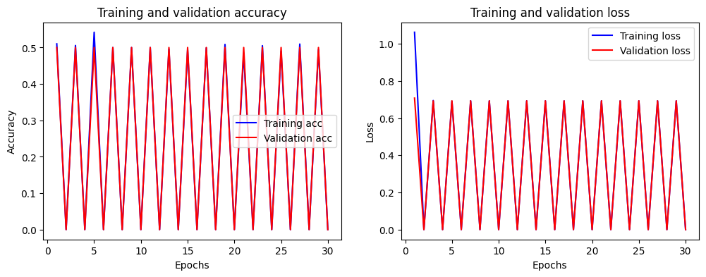

```
50/50 ━━━━━━━━━━━━━━━━━━━━ 77s 2s/step - accuracy: 0.5078 - loss: 0.6931
Validation Loss: 0.69
Validation Accuracy: 0.50
```

```python
# Plot training history
def plot_training_history(history):
    acc = history.history['accuracy']
    val_acc = history.history['val_accuracy']
    loss = history.history['loss']
    val_loss = history.history['val_loss']

    epochs = range(1, len(acc) + 1)

    plt.figure(figsize=(12, 4))

    plt.subplot(1, 2, 1)
    plt.plot(epochs, acc, 'b', label='Training acc')
    plt.plot(epochs, val_acc, 'r', label='Validation acc')
    plt.title('Training and validation accuracy')
    plt.xlabel('Epochs')
    plt.ylabel('Accuracy')
    plt.legend()

    plt.subplot(1, 2, 2)
    plt.plot(epochs, loss, 'b', label='Training loss')
    plt.plot(epochs, val_loss, 'r', label='Validation loss')
    plt.title('Training and validation loss')
    plt.xlabel('Epochs')
    plt.ylabel('Loss')
    plt.legend()

    plt.show()

# Plot training history
plot_training_history(history)

# Evaluate the model
validation_loss, validation_accuracy = model.evaluate(validation_generator)
print(f'Validation Loss: {validation_loss:.2f}')
print(f'Validation Accuracy: {validation_accuracy:.2f}')
```

# 4 2 confusion metric

```
50/50 ━━━━━━━━━━━━━━━━━━━━ 67s 1s/step
```

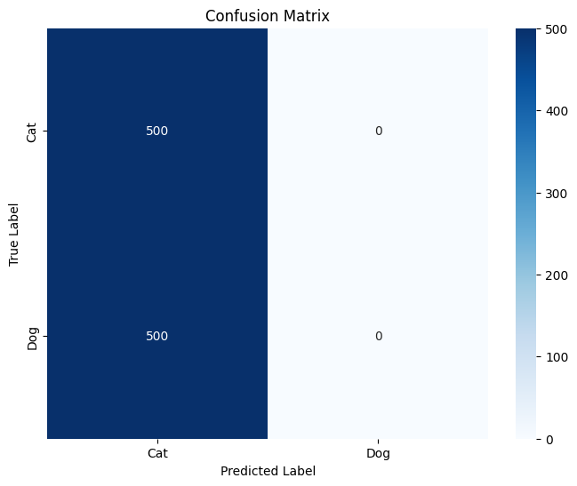

```python
# Make predictions on the validation set
validation_predictions = model.predict(validation_generator)
# Convert probabilities to binary predictions (0 or 1)
validation_predictions_binary = np.where(validation_predictions > 0.5, 1, 0)

# Get the actual labels
actual_labels = validation_generator.classes

# Generate confusion matrix
conf_matrix = confusion_matrix(actual_labels, validation_predictions_binary)

# Plot confusion matrix
plt.figure(figsize=(8, 6))
sns.heatmap(conf_matrix, annot=True, fmt='d', cmap='Blues', xticklabels=['Cat', 'Dog'], yticklabels=['Cat', 'Dog'])
plt.title('Confusion Matrix')
plt.xlabel('Predicted Label')
plt.ylabel('True Label')
plt.show()
```

### 4 3 precision, recall, F1-score,

```python
# Generate classification report
class_report = classification_report(actual_labels, validation_predictions_binary, target_names=['Cat', 'Dog'])

# Print classification report
print("Classification Report:")
print(class_report)
```

```
Classification Report:
              precision    recall  f1-score   support

         Cat       0.50      1.00      0.67       500
         Dog       0.00      0.00      0.00       500

    accuracy                           0.50      1000
   macro avg       0.25      0.50      0.33      1000
weighted avg       0.25      0.50      0.33      1000
```

### 4 4. precision-recall curve.

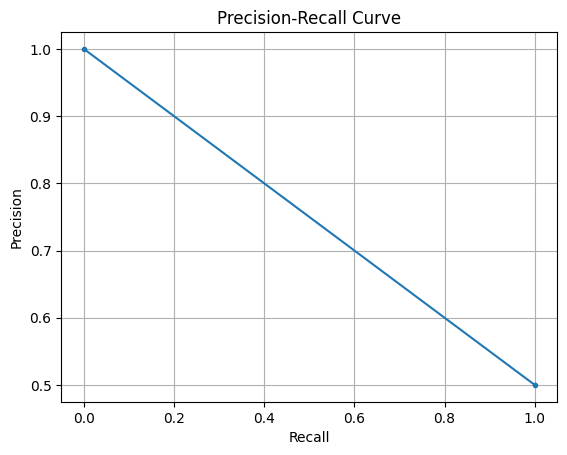

```python
# Compute precision and recall
precision, recall, _ = precision_recall_curve(actual_labels, validation_predictions)

# Plot precision-recall curve
plt.figure()
plt.plot(recall, precision, marker='.')
plt.xlabel('Recall')
plt.ylabel('Precision')
plt.title('Precision-Recall Curve')
plt.grid(True)
plt.show()
```

### 4 5. Explore specific examples in which the model failed to predict correctly.

```python
# Reset the validation generator to start from the beginning
validation_generator.reset()

# Get the predictions from the model
predictions = model.predict(validation_generator)

# Get the true labels
true_labels = validation_generator.classes

# Get the filenames
filenames = validation_generator.filenames

# Find the indices where the predictions are incorrect
incorrect_indices = np.where(predictions != true_labels)[0]

# Display a few examples of incorrect predictions
num_examples_to_display = 5
for i in range(num_examples_to_display):
    index = incorrect_indices[i]
    filename = filenames[index]
    predicted_class = predictions[index]
    true_class = true_labels[index]
    print(f"Example {i+1}:")
    print(f"Filename: {filename}")
    print(f"Predicted class: {predicted_class}, True class: {true_class}")
    # Load and display the image if needed
    # img = plt.imread(os.path.join(validation_dir, filename))
    # plt.imshow(img)
    # plt.show()
    print()
```

```
50/50 ━━━━━━━━━━━━━━━━━━━━ 91s 2s/step
Example 1:
Filename: cats\cat.1000.jpg
Predicted class: [0.49978817], True class: 0

Example 2:
Filename: cats\cat.1000.jpg
Predicted class: [0.49978817], True class: 0

Example 3:
Filename: cats\cat.1000.jpg
Predicted class: [0.49978817], True class: 0

Example 4:
Filename: cats\cat.1000.jpg
Predicted class: [0.49978817], True class: 0

Example 5:
Filename: cats\cat.1000.jpg
Predicted class: [0.49978817], True class: 0
```

### Conclusion

Based on the prediction:

**Classification Report:**

- Precision for predicting cats (Cat) is 0.50, indicating that when the model predicts an instance as a cat, it is correct 50% of the time.
- Recall for cats is 1.00, suggesting that the model successfully identifies all actual cat instances.
- The F1-score for cats is 0.67, which is a harmonic mean of precision and recall, providing a balance between the two metrics.
- For dogs, the precision, recall, and F1-score are all 0.00, indicating that the model fails to correctly predict any instances of dogs.
- The overall accuracy of the model is 0.50, which is relatively low.